# PD5

Ada Gąssowska i Mikołaj Jakubowski

6 grudnia 2019

## Wprowadzenie

Celem ankiety było sprawdzenie jak odczytujemy dane z bardzo złych wykresów. Ankietę rozesłaliśmy wśród naszych znajomych, można więc założyć, że grupą docelową byli ludzie w wieku 20-22 lata.

## Wykres pierwszy

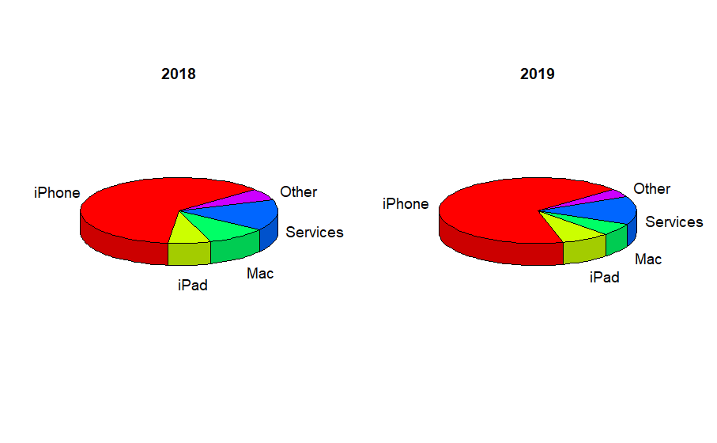

Najpierw ankietowani mieli odpowiedzieć na pytania dotyczące wykresów reprezentujących sprzedaż w jakimś sklepie sprzedająącym produkty Apple’a. Dane zostały przedstawione na wykresach kołowych 3D. Ten typ wykresu uważany jest za jeden z najgorszych i najmniej czytelnych, chcieliśmy więc sprawdzic na ile dobrze odczytują go nasi ankietowani.

Pierwszym zadaniem ankietowanych było odpowiedzenie na pytanie o różnicę między udziałem “Services”, a udziałem sprzedaży Mac’ów w całym dochodzie w 2018 roku. Udział sprzedaży Mac’ów wynosił 10%, a udział “Services” - 15% (tak więc był 1,5 raza większy). Ankietowani mogli zaznaczyć jedną z trzech odpowiedzi: “udział”Services" był 1,5 raza większy“,”Udział “Services” był mniej więcej taki sam (+/- 1%)" oraz “Udział”Services" był 1,5 raza mniejszy“. Poprawenie odpowiedziało 56% ankietowanych, jednak dosyć dużo bo 37% odpowiedziao, że udział ten był mniej więcej taki sam.

Drugim zadaniem było porównanie zysków z IPhone’ów w 2018 i 2019 roku. W 2018 roku wyniósł on 62% całego zysku, a w 2019 - 68%. Ankietowani mieli odpowiedzieć, czy zysk ten wzrósł, zmalał, czy nie zminieł się. Tu ankietowani odpowiedzieli wyjątkowo dobrze, bo aż 88% osób odpowiedziało że zysk wzrósł. Pozostałe 12 zaznaczyło, że się nie zmienił.

W trzecim pytaniu trzeba było określić ile procent według ankietowanego wniosła sprzedaż Mac’ów w 2018 roku (wniosła ona 10%). Do wyboru były 4 odpowiedzi: 5, 10, 15 i 20 procent. Tu jedynie połowa osób odpowiedzła poprawnie. 38% osób uznało że było to 15%, natomiast odpowiedzi 5% i 20% zadeklarowało po 6% ankietowanych. Ciekawe jest, że dużo więcej osób zawyżyło wynik, niż go obniżyło (a przecież odpowiedzi 5% i 15% różnią się o tyle samo od 10%).

Podsumowując, możemy z czystym sumieniem napisać, że prawdą jest stwierdzenie “Wykresy kołowe są mało czytelne”. Mimo wszystko, przewidywaliśmy, że ankietowani poradzą sobie jeszcze gorzej. Może osoby w naszym wieku są przyzwyczajone do wykresów kołowych, i nauczyły się “mniej więcej” odczytywać z nich dane? Nawet jeśli, na przyszłość raczej nie będziemy używac tego rodzaju przedstawiania danych.

## Wykres drugi

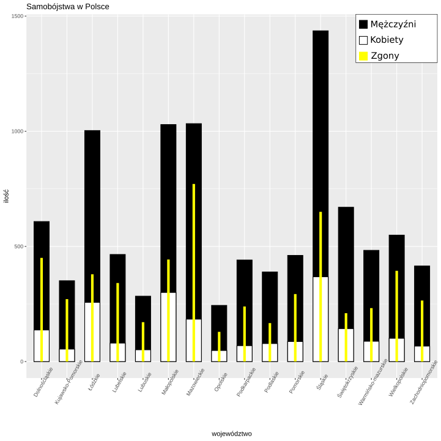

Wykres przedstawia ilość prób samobójczych w poszczególnych województwach (czarny słupek - mężczyźni, biały kobiety) oraz śmiertelność tych prob (żółty słupek w środku).

Wykres został celowo stworzony w sposób nieczytelny: -małe napisy -męczoce dla oczu zestawienie kolorów -słupki nachodzące na siebie

W ankiecie zadane zostało 5 prostych pytań kontrolnych(typu prawda/fałsz), mających na celu sprawdzić jak dane z wykresu zapadają odbiorcy w pamięć.

1. W każdym z województw więcej prób podejmują mężczyźni. (PRAWDA)

Tutaj 93.8% ankietowanych się nie pomyliło. Jak można się było domyślić największy słupek rzuca się w oczy niezależnie od okoliczności.

2. Najwięcej prób samobójczych zakończonych zgonem, odnotowano w województwie Śląskim. (FAŁSZ)

Pytanie to miało na celu sprawdzić czytelność żółtego cienkiego słupka w środku. 43.8% ankietowanych odpowiedziało na nie błędnie. Jest to prawie połowa, więc można wnioskować że umieszczanie go w środku tak wąskim nie jest najlepszym pomysłem.

3. Większość kobiet podejmujących próby samobójcze, robi to ze skutkiem śmiertelnym. (FAŁSZ)

To tak naprawdę pytanie sprawdzającą wiarygodność ankietowanego. Takiej informacji nie ma przedstawionej nigdzie na wykresie i tylko jedna osoba zaznaczyła ją jako poprawną.

4. Najwięcej mężczyzn podejmuje próby w województwie Mazowieckim. (FAŁSZ)

100% poprawnych odpowiedzi. Tutaj zmyłką miał być najwyższy żółty słupek w tej kategorii.

5. Najmniej prób odnotowano w województwie Opolskim. (PRAWDA)

Oczywistym jest, że ankietowani zwracają uwagę na to co największe, ale czy na to co najmniejsze również? Na to pytanie poprawnie odpowiedziała tylko połowa ankietowanych. Prawdopodobnie możnaby zwiekszyć zapamiętywalność tego fragmentu gdybyśmy posortowali słupki w kolejności malejącej.

Podsumowanie: Jak można zauważyć, niektóre “dobre” praktyki tworzenia wykresów są przydatne a niektóre nieco mniej i nie mają tak dużego wpływu na czytelność. Po tak rażącym w oczy kolorami wykresie można było się spodziewać dużo gorszych wyników, ale jednak ankietowani poradzili sobie stosunkowo dobrze z zadanymi pytaniami.